# Gene Expression data analysis of ETS2 mediated tumor suppressive function and MET oncogene inhibition in human non-small cell lung cancer

Yahya Al Sabeh

2024-01-16

## Background

Researchers performed gene expression profiling using Human Gene 1.0 ST platform of 80 lung adenocarcinomas and 30 normal lung tissues to better understand the biology of this significant fraction of NSCLC. Overall design: Lung adenocarcinomas were comprised of never-smoker (n=40) and smoker (n=40) adenocarcinomas. Furthermore, (n=30) of the never-smoker cases normal lung tissue was provided as control. Gene expression profiling was performed on the samples to identify differentially expressed profiles between lung adenocarcinomas and normal lung tissues.

```r
library(oligo)
library(limma)
library(fpc)
library(Biobase)
```

## Loading data and dataset annotation

```r
dir.path <- "C:\\Users\\Yahya\\Downloads\\GSE43458_RAW\\"
fns <- sort(list.celfiles(path=dir.path,full.names=TRUE))

data.affy <- read.celfiles(filenames=fns)
```

```
## Platform design info loaded.
```

```r
raw_data <-exprs(data.affy)
```

Previewing data

```r
head(raw_data)[1:5]
```

```
## [1] 8393  201 7837  156  117
```

```r
head(probeNames(data.affy))
```

```
## [1] "7981326" "8095005" "8100310" "7948117" "8155877" "7900585"
```

Annotating data

```r
colnames(raw_data)[1:40]<-paste0(rep(('LAN'), each=40),"_",1:40)
colnames(raw_data)[41:70]<-paste0(rep(('Normal'), each=30),"_",1:30)
colnames(raw_data)[71:110]<-paste0(rep(('LAS'), each=40),"_",1:40)
colnames(raw_data)
```

```
##   [1] "LAN_1"     "LAN_2"     "LAN_3"     "LAN_4"     "LAN_5"     "LAN_6"
##   [7] "LAN_7"     "LAN_8"     "LAN_9"     "LAN_10"    "LAN_11"    "LAN_12"
##  [13] "LAN_13"    "LAN_14"    "LAN_15"    "LAN_16"    "LAN_17"    "LAN_18"
##  [19] "LAN_19"    "LAN_20"    "LAN_21"    "LAN_22"    "LAN_23"    "LAN_24"
##  [25] "LAN_25"    "LAN_26"    "LAN_27"    "LAN_28"    "LAN_29"    "LAN_30"
##  [31] "LAN_31"    "LAN_32"    "LAN_33"    "LAN_34"    "LAN_35"    "LAN_36"
##  [37] "LAN_37"    "LAN_38"    "LAN_39"    "LAN_40"    "Normal_1"  "Normal_2"
##  [43] "Normal_3"  "Normal_4"  "Normal_5"  "Normal_6"  "Normal_7"  "Normal_8"
##  [49] "Normal_9"  "Normal_10" "Normal_11" "Normal_12" "Normal_13" "Normal_14"
##  [55] "Normal_15" "Normal_16" "Normal_17" "Normal_18" "Normal_19" "Normal_20"
##  [61] "Normal_21" "Normal_22" "Normal_23" "Normal_24" "Normal_25" "Normal_26"
##  [67] "Normal_27" "Normal_28" "Normal_29" "Normal_30" "LAS_1"     "LAS_2"
##  [73] "LAS_3"     "LAS_4"     "LAS_5"     "LAS_6"     "LAS_7"     "LAS_8"
##  [79] "LAS_9"     "LAS_10"    "LAS_11"    "LAS_12"    "LAS_13"    "LAS_14"
##  [85] "LAS_15"    "LAS_16"    "LAS_17"    "LAS_18"    "LAS_19"    "LAS_20"
##  [91] "LAS_21"    "LAS_22"    "LAS_23"    "LAS_24"    "LAS_25"    "LAS_26"
##  [97] "LAS_27"    "LAS_28"    "LAS_29"    "LAS_30"    "LAS_31"    "LAS_32"
## [103] "LAS_33"    "LAS_34"    "LAS_35"    "LAS_36"    "LAS_37"    "LAS_38"
## [109] "LAS_39"    "LAS_40"
```

Simple Log transform, Log2(Intensity)

```r
log2_raw<- log2(raw_data)
```

## Sample Outlier Detection

### PCA plot

```r
PCA_raw <-prcomp(t(log2_raw), scale. = FALSE)

dataGG <- data.frame(PC1 = PCA_raw$x[,1], PC2 = PCA_raw$x[,2])
```

Reframing window and plotting

```r
cat(max(dataGG[,1]),min(dataGG[,1]),max(dataGG[,2]),min(dataGG[,2]))
```

```
## 719.5029 -1432.42 537.556 -373.1064
```

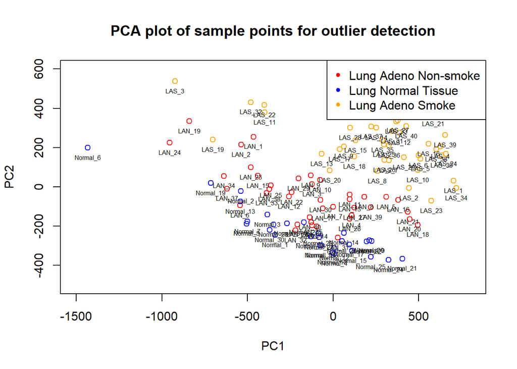

```r
plot(dataGG[1:40,], col='red', main='PCA plot of sample points for outlier detection', xlim=c(-1500,800), ylim=c(-500,600))
points(dataGG[41:70,], col='blue')
points(dataGG[71:110,], col='orange')
legend("topright", legend=c('Lung Adeno Non-smoke', 'Lung Normal Tissue', 'Lung Adeno Smoke'), col=c('red', 'blue', 'orange'), pch=20)
text(dataGG,label=dimnames(dataGG)[[1]],pos=1,cex=0.5)
```

Normal 6, LAS 19, and LAS3 are all likely outliers

### Sample CV vs Mean Plot

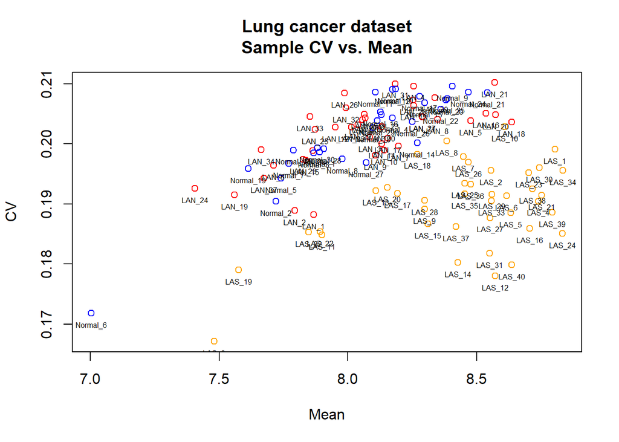

```r
dat.mean <- apply(log2_raw,2,mean)
dat.sd <- sqrt(apply(log2_raw,2,var))
dat.cv <- dat.sd/dat.mean #calculate cv
par(mfrow=c(1,1))
plot(dat.mean,dat.cv,main="Lung cancer dataset\nSample CV vs. Mean",xlab="Mean",ylab="CV",col='blue',cex=1.5,type="n")
points(dat.mean[1:40],dat.cv[1:40], col='red')
points(dat.mean[41:70],dat.cv[41:70], col='blue')
points(dat.mean[71:110], dat.cv[71:110], col='orange')
text(dat.mean,dat.cv,label=dimnames(log2_raw)[[2]],pos=1,cex=0.5)
```

Normal 6and LAS3 are all likely outliers

### Pearson Correlation of intensity data

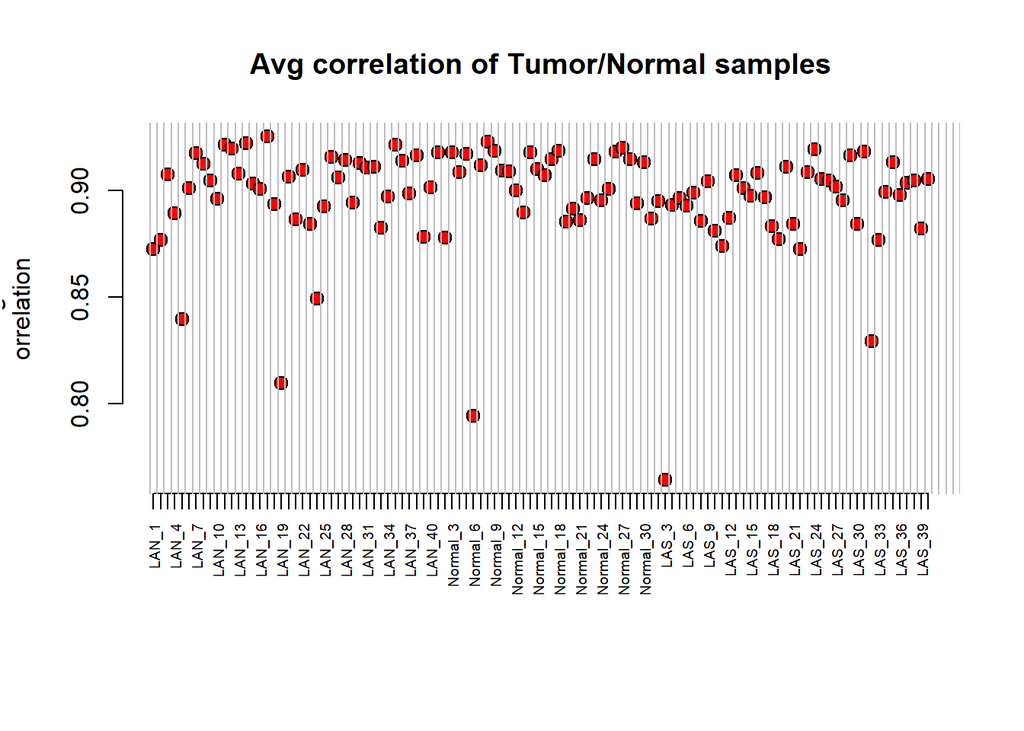

```r
dat <- t(raw_data)
corr_matrix <- cor(raw_data, use="pairwise.complete.obs", method="pearson")
dat.avg <- apply(corr_matrix,1,mean)
par(oma=c(3,0.1,0.1,0.1))
plot(c(1,length(dat.avg)),range(dat.avg),type="n",xlab="",ylab="Avg c
orrelation",main="Avg correlation of Tumor/Normal samples",axes=F)
points(dat.avg,bg="red",col=1,pch=21,cex=1.25)
axis(1,at=c(1:length(dat.avg)),labels=dimnames(dat)[[1]],las=2,cex.lab=0.4,cex.axis=0.6)
axis(2)
abline(v=seq(0.5,120.5,1),col="grey")
```

LAS 3, and Normal6 are Possible outliers. Possibly LAN19

### Hierarchical Clustering using Euclidean Distance

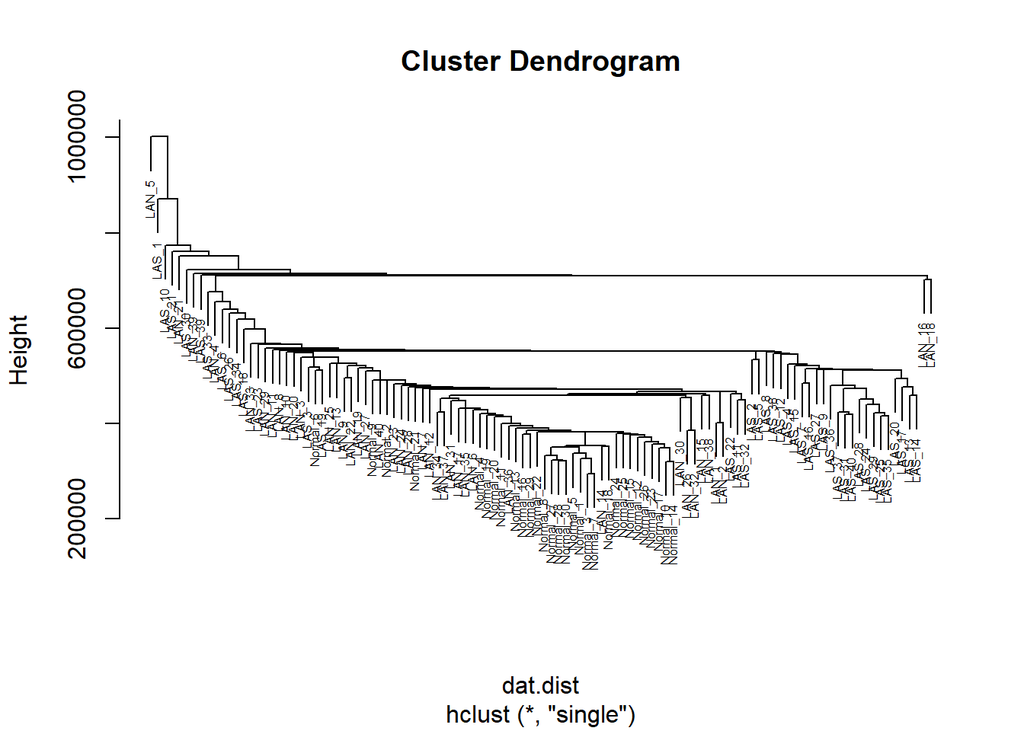

```r
par(mfrow=c(1,1))
dat <- t(raw_data) #transpose dat
dat.dist <- dist(dat,method="euclidean") # calculate distance
dat.clust <- hclust(dat.dist,method="single") # calculate cluster
plot(dat.clust,labels=names(dat),cex=0.5)
```

LAN5 Possible outliers

### Pairwise Pearson Correlation Heatmap

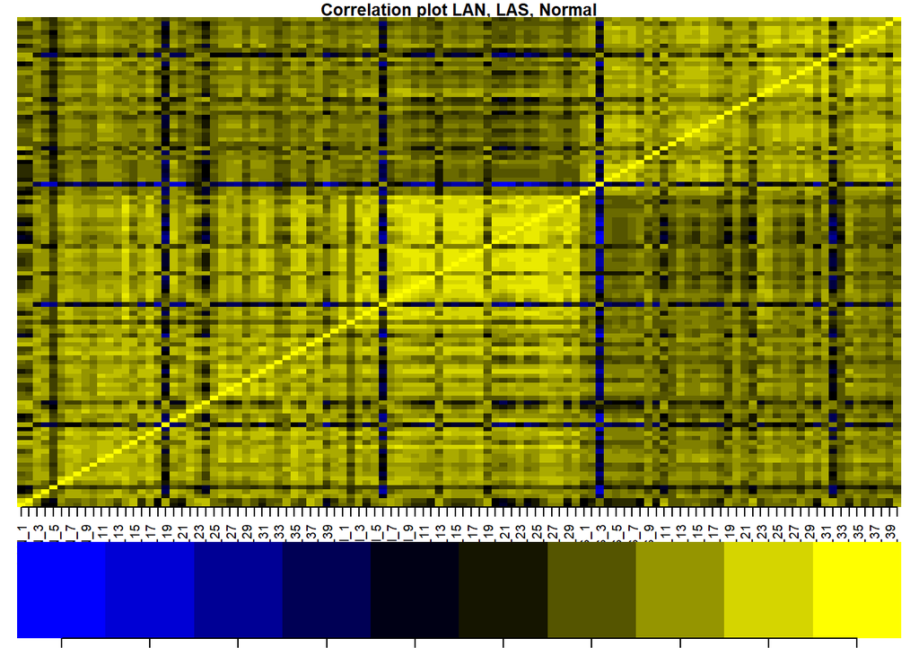

```r
library(gplots)
corr_matrix = cor(raw_data, use="pairwise.complete.obs", method="pearson")
layout(matrix(c(1,1,1,1,1,1,1,1,2,2), 5, 2, byrow = TRUE))
par(mar=c(1,1,1,1))
cx<-rev(colorpanel(25, "yellow","black","blue"))
leg<- seq(min(corr_matrix, na.rm=T), max(corr_matrix, na.rm=T), length=10)
image(corr_matrix, main="Correlation plot LAN, LAS, Normal", axes=F, col=cx)
axis(1, at=seq(0, 1, length=ncol(corr_matrix)), label=dimnames(corr_matrix)[[2]], cex.axis=0.9, las=2)
image(as.matrix(leg), col=cx, axes=F)
tmp<-round(leg,2)
axis(1, at=seq(0,1,length=length(leg)), labels=tmp, cex.axis=1)
```

Normal 6, LAS 3 are definely outliers.

LAN 19 and LAN32 are suspect however they are not corroborated by other plots.

So only Normal 6 and LAS3 will be removed.

## Sample Outlier Removal

```r
colnames(data.affy)[1:40]<-paste0(rep(('LAN'), each=40),"_",1:40)
colnames(data.affy)[41:70]<-paste0(rep(('Normal'), each=30),"_",1:30)
colnames(data.affy)[71:110]<-paste0(rep(('LAS'), each=40),"_",1:40)
colnames(data.affy)
```

```
##   [1] "LAN_1"     "LAN_2"     "LAN_3"     "LAN_4"     "LAN_5"     "LAN_6"
##   [7] "LAN_7"     "LAN_8"     "LAN_9"     "LAN_10"    "LAN_11"    "LAN_12"
##  [13] "LAN_13"    "LAN_14"    "LAN_15"    "LAN_16"    "LAN_17"    "LAN_18"
##  [19] "LAN_19"    "LAN_20"    "LAN_21"    "LAN_22"    "LAN_23"    "LAN_24"
##  [25] "LAN_25"    "LAN_26"    "LAN_27"    "LAN_28"    "LAN_29"    "LAN_30"
##  [31] "LAN_31"    "LAN_32"    "LAN_33"    "LAN_34"    "LAN_35"    "LAN_36"
##  [37] "LAN_37"    "LAN_38"    "LAN_39"    "LAN_40"    "Normal_1"  "Normal_2"
##  [43] "Normal_3"  "Normal_4"  "Normal_5"  "Normal_6"  "Normal_7"  "Normal_8"
##  [49] "Normal_9"  "Normal_10" "Normal_11" "Normal_12" "Normal_13" "Normal_14"
##  [55] "Normal_15" "Normal_16" "Normal_17" "Normal_18" "Normal_19" "Normal_20"
##  [61] "Normal_21" "Normal_22" "Normal_23" "Normal_24" "Normal_25" "Normal_26"
##  [67] "Normal_27" "Normal_28" "Normal_29" "Normal_30" "LAS_1"     "LAS_2"
##  [73] "LAS_3"     "LAS_4"     "LAS_5"     "LAS_6"     "LAS_7"     "LAS_8"
##  [79] "LAS_9"     "LAS_10"    "LAS_11"    "LAS_12"    "LAS_13"    "LAS_14"
##  [85] "LAS_15"    "LAS_16"    "LAS_17"    "LAS_18"    "LAS_19"    "LAS_20"
##  [91] "LAS_21"    "LAS_22"    "LAS_23"    "LAS_24"    "LAS_25"    "LAS_26"
##  [97] "LAS_27"    "LAS_28"    "LAS_29"    "LAS_30"    "LAS_31"    "LAS_32"
## [103] "LAS_33"    "LAS_34"    "LAS_35"    "LAS_36"    "LAS_37"    "LAS_38"
## [109] "LAS_39"    "LAS_40"
```

```r
outliers<-c('Normal_6', 'LAS_3')
raw_data_filt<-data.affy[,!(colnames(data.affy) %in% outliers)]
colnames(raw_data_filt)
```

```
##   [1] "LAN_1"     "LAN_2"     "LAN_3"     "LAN_4"     "LAN_5"     "LAN_6"
##   [7] "LAN_7"     "LAN_8"     "LAN_9"     "LAN_10"    "LAN_11"    "LAN_12"
##  [13] "LAN_13"    "LAN_14"    "LAN_15"    "LAN_16"    "LAN_17"    "LAN_18"
##  [19] "LAN_19"    "LAN_20"    "LAN_21"    "LAN_22"    "LAN_23"    "LAN_24"
##  [25] "LAN_25"    "LAN_26"    "LAN_27"    "LAN_28"    "LAN_29"    "LAN_30"
##  [31] "LAN_31"    "LAN_32"    "LAN_33"    "LAN_34"    "LAN_35"    "LAN_36"
##  [37] "LAN_37"    "LAN_38"    "LAN_39"    "LAN_40"    "Normal_1"  "Normal_2"
##  [43] "Normal_3"  "Normal_4"  "Normal_5"  "Normal_7"  "Normal_8"  "Normal_9"
##  [49] "Normal_10" "Normal_11" "Normal_12" "Normal_13" "Normal_14" "Normal_15"
##  [55] "Normal_16" "Normal_17" "Normal_18" "Normal_19" "Normal_20" "Normal_21"
##  [61] "Normal_22" "Normal_23" "Normal_24" "Normal_25" "Normal_26" "Normal_27"
##  [67] "Normal_28" "Normal_29" "Normal_30" "LAS_1"     "LAS_2"     "LAS_4"
##  [73] "LAS_5"     "LAS_6"     "LAS_7"     "LAS_8"     "LAS_9"     "LAS_10"
##  [79] "LAS_11"    "LAS_12"    "LAS_13"    "LAS_14"    "LAS_15"    "LAS_16"
##  [85] "LAS_17"    "LAS_18"    "LAS_19"    "LAS_20"    "LAS_21"    "LAS_22"
##  [91] "LAS_23"    "LAS_24"    "LAS_25"    "LAS_26"    "LAS_27"    "LAS_28"
##  [97] "LAS_29"    "LAS_30"    "LAS_31"    "LAS_32"    "LAS_33"    "LAS_34"
## [103] "LAS_35"    "LAS_36"    "LAS_37"    "LAS_38"    "LAS_39"    "LAS_40"
```

## Normalizing counts and applying background correction

```r
normalised<-rma(raw_data_filt)
```

```
## Background correcting
## Normalizing
## Calculating Expression
```

```r
eset<-exprs(normalised)
```

## Filtering low genes by Oligo Method

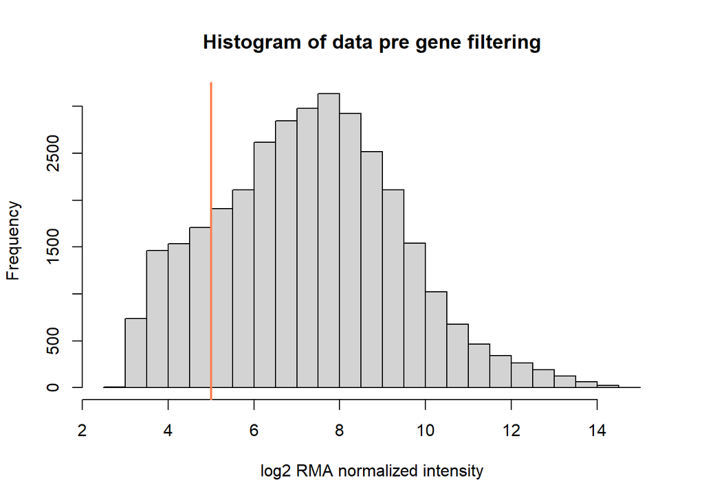

```r
par(mfrow=c(1,1))
hist_res<-hist(rowMedians(eset), xlab='log2 RMA normalized intensity', main='Histogram of data pre gene filtering')

threshold<-5

abline(v=threshold, col="coral", lwd=2)
```

Now we check if at least 30 expression values across genes are greater than this threshold

```r
samples_cutoff<-30

idx_man_threshold<-apply(eset, 1, function(x){
  sum(x > threshold) >=samples_cutoff})

table(idx_man_threshold)
```

```
## idx_man_threshold
## FALSE  TRUE
##  4757 28540
```

Remove the genes

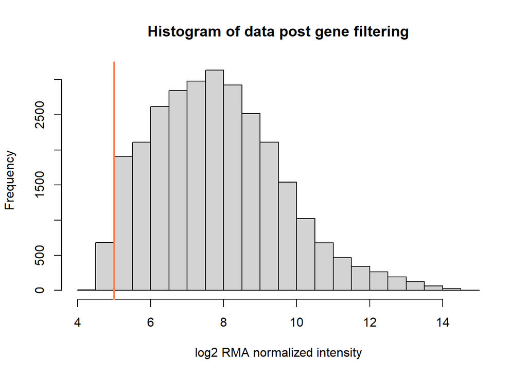

```r
eset<-subset(eset, idx_man_threshold)
hist_res<-hist(rowMedians(eset), xlab='log2 RMA normalized intensity', main='Histogram of data post gene filtering')
abline(v=threshold, col="coral", lwd=2)
```

## Statistical Analysis- 2-way Anova with 2 Levels

```r
aov2.all.genes <- function(x,s1,s2, s3, s4) {
  x1 <- as.numeric(x[s1])
  x2 <- as.numeric(x[s2])
  y1 <- as.numeric(x[s3])
  y2 <- as.numeric(x[s4])
  fac <- c(rep('S-',length(x1)), rep('S+',length(x2)), rep('S-', 40), rep('S+',39), rep('S-',length(y2)))
  can <- c(rep('C+', 40), rep('C-', length(y2)), rep('C+', length(x2)),rep('C+', length(y1)),rep('C-', length(y2)))
  a.dat <- data.frame(as.factor(fac),as.factor(can), c(x1,x2,y1,y2))
  names(a.dat) <- c('smoke','cancer','express')
  p.out <- summary(aov(express~smoke+cancer, a.dat))[[1]][1:2,5]
  #p.out <- summary(aov(express~factor, a.dat))[[1]][1,4]   # use to get F-statistic
  return(as.numeric(p.out))
}
rawp <- apply(eset,1,aov2.all.genes,s1=colnames(eset[,1:69]),s2=colnames(eset[,70:108]),
              s3=c(colnames(eset[,1:40]),colnames(eset[,70:108])), s4=c(colnames(eset[,41:69])))
rownames(rawp)<-c('smoke','cancer')
```

## Adjusting p-value using the Bonferroni Correction

```r
library(multtest)
```

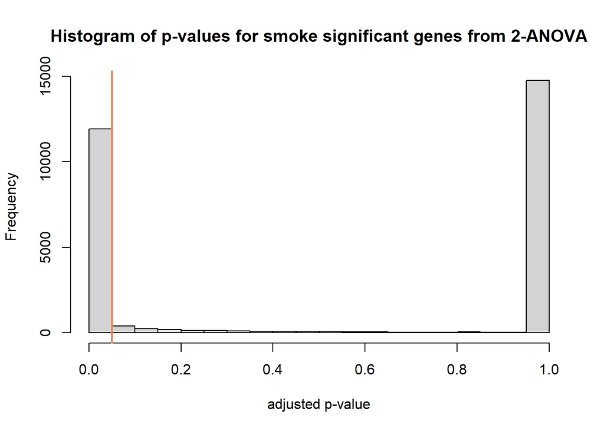

```r
res1_smoke<-mt.rawp2adjp(rawp['smoke',],c("Holm","Bonferroni"))
res1_cancer<-mt.rawp2adjp(rawp['cancer',],c("Holm","Bonferroni"))

par(mfrow=c(1,1))
smoke_adjp<-res1_smoke$adjp[,3]
hist(smoke_adjp, main='Histogram of p-values for smoke significant genes from 2-ANOVA', xlab='adjusted p-value')
abline(v=0.05, col="coral", lwd=2)
```

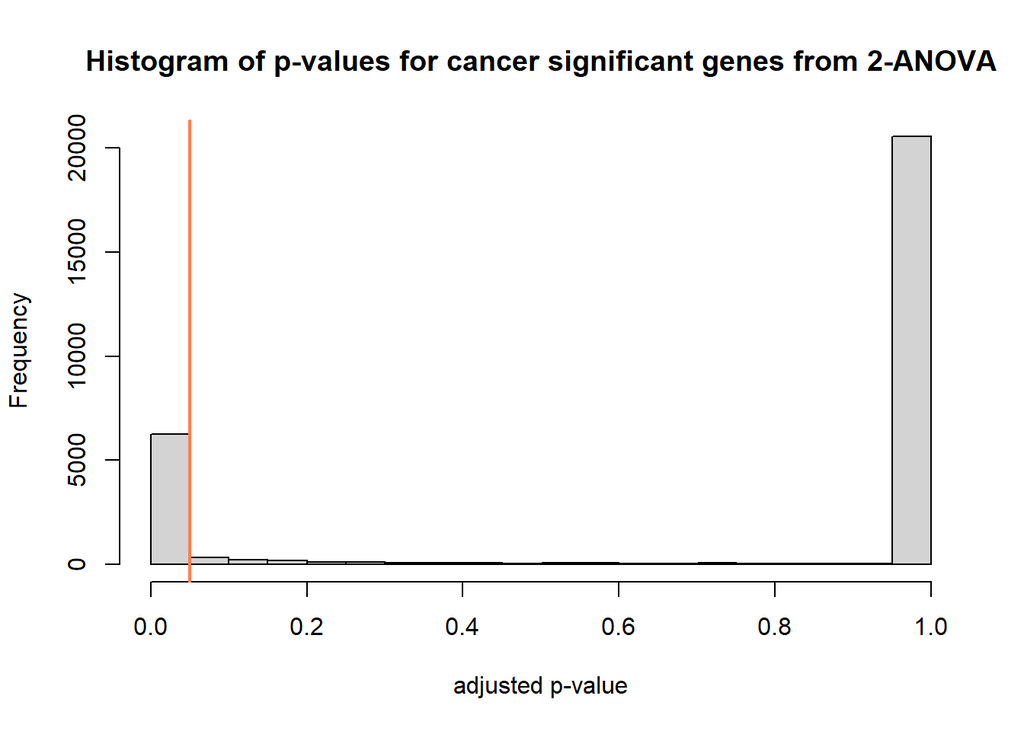

```r
cancer_adjp<-res1_cancer$adjp[,3]
hist(cancer_adjp, main='Histogram of p-values for cancer significant genes from 2-ANOVA', xlab='adjusted p-value')
abline(v=0.05, col="coral", lwd=2)
```

## DEG Volcano Plots

```r
control_smoke <- apply(eset[,1:69], 1, mean)
exp_smoke <- apply(eset[,70:108], 1, mean)
foldlog_smoke <- exp_smoke-control_smoke

lin_foldsmoke<- 2^foldlog_smoke
linMax_foldsmoke<- max(lin_foldsmoke)
linMax_foldsmoke
```

```
## [1] 6.099704
```

```r
linMin_foldsmoke<- min(lin_foldsmoke)
linMin_foldsmoke
```

```
## [1] 0.1823265
```

```r
orderedP_smoke<-res1_smoke$adjp[,3][order(res1_smoke$index)]
```

### DEG Volcano Plot 1

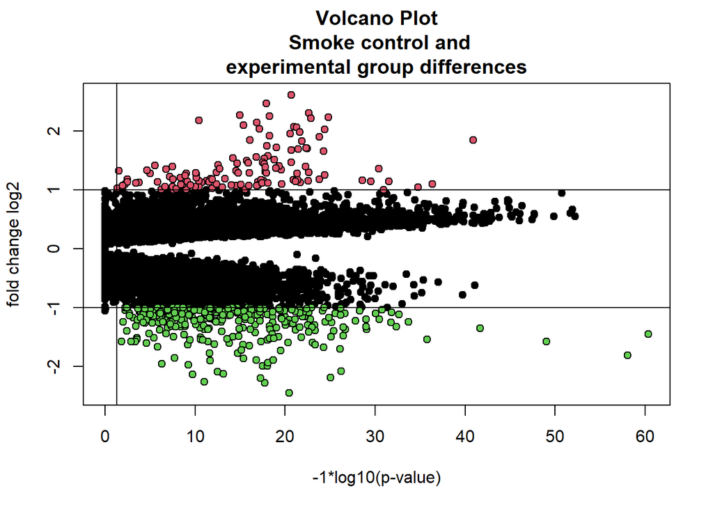

```r
par(mfrow=c(1,1))
pv_trans<--log10(orderedP_smoke)
plot(range(pv_trans),range(foldlog_smoke),type='n',xlab='-1*log10(p-value)',ylab='fold change log2',main='Volcano Plot\n Smoke control and
experimental group differences')
points(pv_trans,foldlog_smoke,col='black',pch=21,bg=1)
points(pv_trans[(pv_trans> -log10(.05)&foldlog_smoke>log2(2))],foldlog_smoke[(pv_trans> -
                                                                   log10(.05)&foldlog_smoke>log2(2))],col=1,bg=2,pch=21)
points(pv_trans[(pv_trans> -log10(.05)&foldlog_smoke< -
                     log2(2))],foldlog_smoke[(pv_trans> -log10(.05)&foldlog_smoke< -
                                             log2(2))],col=1,bg=3,pch=21)
abline(v= -log10(.05))
abline(h= -log2(2))
abline(h=log2(2))
```

```r
sig_smokegenes<-rownames(eset[which(pv_trans>-log10(0.05)),])
head(sig_smokegenes)
```

```
## [1] "7892504" "7892506" "7892507" "7892512" "7892515" "7892517"
```

```r
express_smokegenes<-rownames(eset[which(abs(foldlog_smoke)>1),])
head(express_smokegenes)
```

```
## [1] "7893230" "7893306" "7893570" "7893617" "7894270" "7894584"
```

```r
Significant_SmokeGenes<-eset[intersect(sig_smokegenes,express_smokegenes),]
head(Significant_SmokeGenes)
```

```
##             LAN_1     LAN_2    LAN_3    LAN_4    LAN_5    LAN_6    LAN_7
## 7893230  4.975067  5.188107 6.182333 6.305981 3.965489 6.644053 6.558944
## 7893306 10.419149 10.141759 9.233388 8.909203 8.647043 8.939780 8.842347
## 7893570  8.082805  6.634877 7.346293 6.917020 5.166630 7.561204 6.490368
## 7893617  6.933288  7.429237 6.753818 6.684737 6.438077 6.087687 6.773731
## 7894270  4.483334  4.089018 4.683509 4.300552 6.906570 3.998204 5.159247
## 7894584  7.341297  7.119841 6.485340 6.312317 6.263867 6.184043 6.156978
##            LAN_8    LAN_9   LAN_10   LAN_11   LAN_12   LAN_13   LAN_14   LAN_15
## 7893230 6.617777 5.797496 6.239724 6.450641 5.686704 5.712984 5.865629 6.335317
## 7893306 8.765850 9.735218 8.682628 9.688145 9.182170 8.812525 9.596125 9.356972
## 7893570 6.577098 7.801637 7.171993 7.756452 6.272962 7.510897 6.592953 6.987981
## 7893617 7.451082 6.820454 6.469741 6.713022 7.223672 7.425900 6.946128 7.133505
## 7894270 4.408271 4.533210 3.831518 5.331356 4.447089 4.387060 5.845389 3.783068
## 7894584 6.271226 6.600060 5.960196 7.038283 6.701768 6.237336 6.736861 6.822723
##           LAN_16   LAN_17   LAN_18    LAN_19   LAN_20   LAN_21   LAN_22
```

[output cut: 90 more lines]

### DEG Volcano Plot 2

```r
#Volcano plot #2
control_cancer <- apply(eset[,41:69], 1, mean)
exp_cancer <- apply(eset[,c(colnames(eset[,70:108]), colnames(eset[,1:40]))], 1, mean)
foldlog_cancer <- exp_cancer-control_cancer

lin_foldcancer<- 2^foldlog_cancer
linMax_foldcancer<- max(lin_foldcancer)
linMax_foldcancer
```

```
## [1] 21.43166
```

```r
linMin_foldsmoke<- min(lin_foldcancer)
linMin_foldsmoke
```

```
## [1] 0.04880641
```

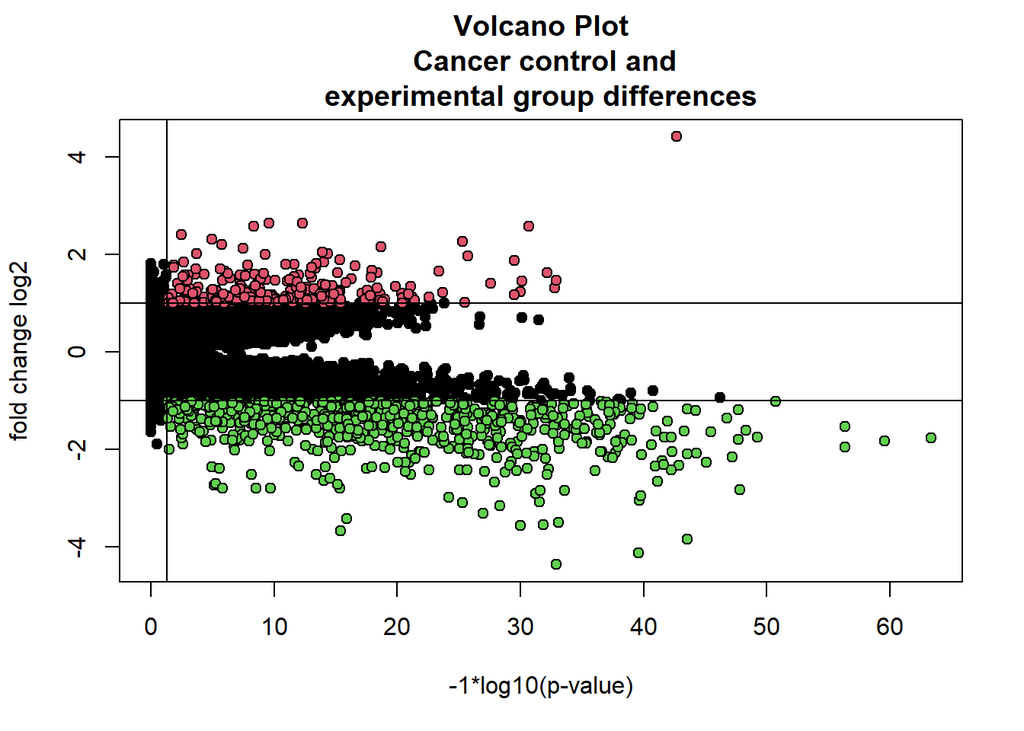

```r
orderedP_cancer<-res1_cancer$adjp[,3][order(res1_cancer$index)]



par(mfrow=c(1,1))
pv_trans<--log10(orderedP_cancer)
plot(range(pv_trans),range(foldlog_cancer),type='n',xlab='-1*log10(p-value)',ylab='fold change log2',main='Volcano Plot\n Cancer control and
experimental group differences')
points(pv_trans,foldlog_cancer,col='black',pch=21,bg=1)
points(pv_trans[(pv_trans> -log10(.05)&foldlog_cancer>log2(2))],foldlog_cancer[(pv_trans> -
                                                                                log10(.05)&foldlog_cancer>log2(2))],col=1,bg=2,pch=21)
points(pv_trans[(pv_trans> -log10(.05)&foldlog_cancer< -
                   log2(2))],foldlog_cancer[(pv_trans> -log10(.05)&foldlog_cancer< -
                                              log2(2))],col=1,bg=3,pch=21)
abline(v= -log10(.05))
abline(h= -log2(2))
abline(h=log2(2))
```

```r
sig_cancergenes<-rownames(eset[which(pv_trans>-log10(0.05)),])
head(sig_cancergenes)
```

```
## [1] "7892514" "7892516" "7892521" "7892522" "7892527" "7892530"
```

```r
express_cancergenes<-rownames(eset[which(abs(foldlog_cancer)>1),])
head(express_cancergenes)
```

```
## [1] "7892779" "7892962" "7892998" "7893028" "7893055" "7893177"
```

```r
Significant_CancerGenes<-eset[intersect(sig_cancergenes,express_cancergenes),]
head(Significant_CancerGenes)
```

```
##            LAN_1    LAN_2    LAN_3    LAN_4    LAN_5    LAN_6    LAN_7    LAN_8
## 7892779 5.660556 6.603556 6.618953 6.332351 7.362822 6.110087 7.149392 7.727259
## 7892962 5.341396 5.866138 6.465854 6.707810 7.520826 6.398018 5.872712 6.481112
## 7892998 8.526523 8.296459 7.843596 8.554162 8.056662 8.165456 8.450053 8.754636
## 7893028 7.106994 6.073300 7.258522 7.124828 7.413492 6.474658 7.253570 7.801733
## 7893055 7.790966 7.033545 8.117356 7.726173 8.350420 7.058467 8.098148 8.591826
## 7893177 6.823878 7.904066 6.383049 7.136071 6.714676 7.041488 7.068511 7.187564
##            LAN_9   LAN_10   LAN_11   LAN_12   LAN_13   LAN_14   LAN_15   LAN_16
## 7892779 7.523052 7.436803 7.318248 6.460202 7.288259 6.782006 5.449727 5.954270
## 7892962 7.906476 6.972229 6.045319 6.216318 7.843966 6.820642 5.971579 6.839652
## 7892998 8.460401 8.845869 7.346517 8.549393 8.595903 8.045798 8.200259 8.091378
## 7893028 7.774294 5.716701 7.516173 6.107825 7.419342 7.180818 6.755498 7.019797
## 7893055 8.339755 8.504883 7.758819 7.063646 7.725044 8.057103 7.420100 7.207119
## 7893177 6.561629 6.686035 5.534646 6.040699 7.368693 6.750721 7.463245 7.139107
##           LAN_17   LAN_18   LAN_19   LAN_20   LAN_21   LAN_22   LAN_23   LAN_24
```

[output cut: 83 more lines]

## Applying Dimensionality reduction and K-Means Clustering Classification Unsupervised Learning approach for predicting membership in two groups.

### Smoke vs Non-smoke Groups

```r
#PCA1

smoke.pca<-prcomp(t(Significant_SmokeGenes))
smoke.loadings<-smoke.pca$x[,1:2]
smoke.loadings[0:5,]
```

```
##               PC1       PC2
## LAN_1  -6.7247968  9.566032
## LAN_2  -0.8002786  7.480605
## LAN_3 -13.9466622 24.300106
## LAN_4  -8.2015884  6.435883
## LAN_5  -5.0079388 31.928162
```

```r
cl_smoke<-kmeans(smoke.loadings, centers=2, iter.max=1000)

library(stringr)
```

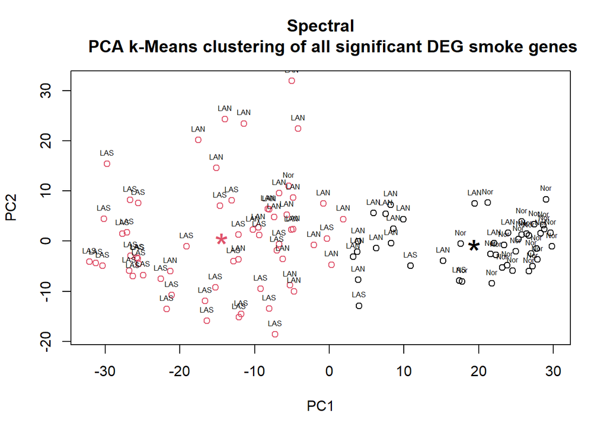

```r
plot(smoke.loadings, col=cl_smoke$cluster, cex=1, main="Spectral
     PCA k-Means clustering of all significant DEG smoke genes")
points(cl_smoke$centers, col = 1:4, pch = '*', cex=2.5)


trunc_labels<-substr(names(cl_smoke$cluster), 1,3)
text(smoke.loadings, trunc_labels, cex=0.5, pos=3)
```

26 errors falsely assigned to Smoking group,so the distinction is not as significant

### Cancer vs Control Groups

```r
cancer.pca<-prcomp(t(Significant_CancerGenes))
cancer.loadings<-cancer.pca$x[,1:2]
cancer.loadings[0:5,]
```

```
##              PC1       PC2
## LAN_1 -11.145839 -3.963817
## LAN_2  -7.789640 -2.638876
## LAN_3 -25.124327  6.223891
## LAN_4 -22.400780 -6.084230
## LAN_5  -9.714932 14.815794
```

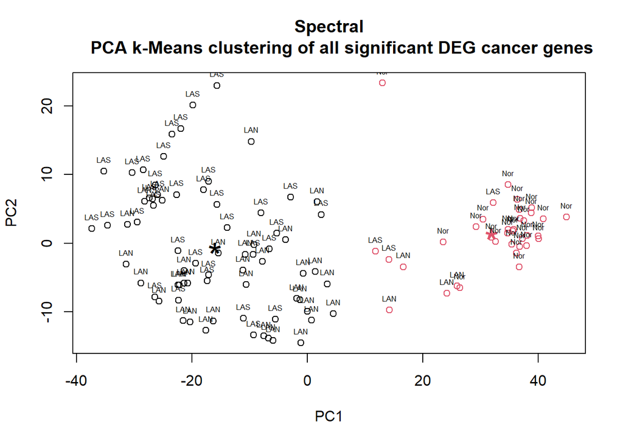

```r
cl_cancer<-kmeans(cancer.loadings, centers=2, iter.max=1000)

library(stringr)
plot(cancer.loadings, col=cl_cancer$cluster, cex=1, main="Spectral
     PCA k-Means clustering of all significant DEG cancer genes")
points(cl_cancer$centers, col = 1:4, pch = '*', cex=2.5)


trunc_labels<-substr(names(cl_cancer$cluster), 1,3)
text(cancer.loadings, trunc_labels, cex=0.5, pos=3)
```

## Top5 Discriminant Genes from Smoke

```r
top_smokeValue<-sort(foldlog_smoke[express_smokegenes], decreasing=TRUE)
top5_smokeGenes<-head(top_smokeValue)
top5_smokeGenes
```

```
##  8053718  8043436  8043470  8043441  8043468  7982377
## 2.608739 2.465502 2.304183 2.266451 2.252305 2.231247
```

```r
bottom5_smokeGenes<-tail(top_smokeValue)
bottom5_smokeGenes
```

```
##   8022655   8058591   8138392   7964722   8082928   8151532
## -2.134045 -2.190357 -2.202782 -2.260333 -2.281984 -2.455404
```

## Top5 Discriminant Genes from Cancer

```r
top_cancerValue<-sort(foldlog_cancer[express_cancergenes], decreasing=TRUE)
top5_cancerGenes<-head(top_cancerValue)
top5_cancerGenes
```

```
##  8096301  8095886  8114964  7944164  7951297  8067140
## 4.421672 2.649503 2.642442 2.588700 2.576419 2.411584
```

```r
bottom5_cancerGenes<-tail(top_cancerValue)
bottom5_cancerGenes
```

```
##   8178771   8125341   7964722   8016841   8013989   8151532
## -3.548995 -3.562454 -3.663130 -3.838836 -4.126136 -4.356786
```